# `Broadband Outage Detection`

### Description:

India is seeing an explosion of new competitors in the Broadband space. 'India Broadband' is a company that is now seeing a lot of customer churn due to customer dissatisfaction because of broadband outages.

The company has now curated a dataset, where it tracks several variables that it believes impact the `outage_duration`. They have tracked three different outage durations, `0` for no outage, `1` for short outages that last anywhere between a few minutes and a maximum of 2 hours, and `2` for long outages that can last from 2 hours to sometimes even a couple of days.

You will now have to use these metrics that the company has tracked to create a machine learning model that will be able to predict the `outage_duration` so that the company can better handle outages and improve customer satisfaction and therefore reduce customer churn.

## 1. Importing Libraries

```python
import numpy as np                   # array/mathematical package
import pandas as pd                  # data manipulation/analysis package
import matplotlib.pyplot as plt      # library for vizualisations in matlab style
import seaborn as sns                # matplot based package for stylised plots
sns.set()                            # set seaborn as default aesthetics in plots
from functools import reduce
from sklearn.model_selection import train_test_split
from sklearn.decomposition import PCA
from sklearn.model_selection import GridSearchCV
from sklearn.metrics import f1_score
```

## 2 Reading Datasets

```python
# broadband data
broadband_df = pd.read_csv('data/broadband_data.csv')

# outage data
outage_df = pd.read_csv('data/outage_data.csv')

# report data
report_df = pd.read_csv('data/report_data.csv')

# server data
server_df = pd.read_csv('data/server_data.csv')

# train data
train_df = pd.read_csv('data/train_data.csv')
```

## 3. Exploring the datasets

#### 3.1 Broadband data

```python
broadband_df.head()
```

|  | id | broadband_type |
| --- | --- | --- |
| 0 | 6597 | broadband_type_8 |
| 1 | 8011 | broadband_type_8 |
| 2 | 2597 | broadband_type_8 |
| 3 | 5022 | broadband_type_8 |
| 4 | 6852 | broadband_type_8 |

```python
# creating a dictionary for broadband types with key as the type and name as the value
broadband_type_dict = {  'broadband_type_8'  : 'ADSL 1',
                         'broadband_type_2'  : 'ADSL 2',
                         'broadband_type_6'  : 'ADSL 2+',
                         'broadband_type_7'  : 'Cable',
                         'broadband_type_4'  : 'Fiber 1',
                         'broadband_type_9'  : 'BPL',
                         'broadband_type_3'  : 'Fiber 2',
                         'broadband_type_10' : 'Fiber High Speed',
                         'broadband_type_1'  : 'Fiber Ultra',
                         'broadband_type_5'  : 'Fiber Ultra Max'}
```

```python
# mapping the values of the dictionary broadband_type_dict based on the broadband_name as the key
broadband_df['broadband_name']=broadband_df.broadband_type.map(broadband_type_dict)
```

```python
broadband_df.head()
```

|  | id | broadband_type | broadband_name |
| --- | --- | --- | --- |
| 0 | 6597 | broadband_type_8 | ADSL 1 |
| 1 | 8011 | broadband_type_8 | ADSL 1 |
| 2 | 2597 | broadband_type_8 | ADSL 1 |
| 3 | 5022 | broadband_type_8 | ADSL 1 |
| 4 | 6852 | broadband_type_8 | ADSL 1 |

```python
broadband_df.tail()
```

|  | id | broadband_type | broadband_name |
| --- | --- | --- | --- |
| 21071 | 3761 | broadband_type_8 | ADSL 1 |
| 21072 | 8720 | broadband_type_8 | ADSL 1 |
| 21073 | 6488 | broadband_type_8 | ADSL 1 |
| 21074 | 878 | broadband_type_8 | ADSL 1 |
| 21075 | 4464 | broadband_type_8 | ADSL 1 |

```python
# shape of the data post mapping with the dictionary
broadband_df.shape
```

```
(21076, 3)
```

```python
# description of the data
broadband_df.describe(include='all')
```

|  | id | broadband_type | broadband_name |
| --- | --- | --- | --- |
| count | 21076.000000 | 21076 | 21076 |
| unique | NaN | 10 | 10 |
| top | NaN | broadband_type_8 | ADSL 1 |
| freq | NaN | 10268 | 10268 |
| mean | 9255.869330 | NaN | NaN |
| std | 5366.730222 | NaN | NaN |
| min | 1.000000 | NaN | NaN |
| 25% | 4599.750000 | NaN | NaN |
| 50% | 9256.500000 | NaN | NaN |
| 75% | 13907.250000 | NaN | NaN |
| max | 18552.000000 | NaN | NaN |

```python
# summary of the dataframe
broadband_df.info()
```

```
<class 'pandas.core.frame.DataFrame'>
RangeIndex: 21076 entries, 0 to 21075
Data columns (total 3 columns):
 #   Column          Non-Null Count  Dtype
---  ------          --------------  -----
 0   id              21076 non-null  int64
 1   broadband_type  21076 non-null  object
 2   broadband_name  21076 non-null  object
dtypes: int64(1), object(2)
memory usage: 494.1+ KB
```

> Seems like id is being treated as int, i.e. as numerical but as we know it is a category and so are the other two columns. Hence changing the datatype in the next step

```python
broadband_df = broadband_df.astype('category')
broadband_df.head()
```

|  | id | broadband_type | broadband_name |
| --- | --- | --- | --- |
| 0 | 6597 | broadband_type_8 | ADSL 1 |
| 1 | 8011 | broadband_type_8 | ADSL 1 |
| 2 | 2597 | broadband_type_8 | ADSL 1 |
| 3 | 5022 | broadband_type_8 | ADSL 1 |
| 4 | 6852 | broadband_type_8 | ADSL 1 |

```python
broadband_df.info()
```

```
<class 'pandas.core.frame.DataFrame'>
RangeIndex: 21076 entries, 0 to 21075
Data columns (total 3 columns):
 #   Column          Non-Null Count  Dtype
---  ------          --------------  -----
 0   id              21076 non-null  category
 1   broadband_type  21076 non-null  category
 2   broadband_name  21076 non-null  category
dtypes: category(3)
memory usage: 868.2 KB
```

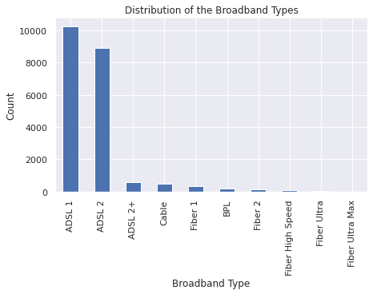

```python
plt.figure(figsize=(7,4))
broadband_df.broadband_name.value_counts().plot(kind='bar')
plt.xlabel('Broadband Type')
plt.ylabel('Count')
plt.title('Distribution of the Broadband Types')
plt.show()
```

> On exploring the data set we find that the broadband company has recorded most of the complaints where the broadband type was Either ADSL 1 or ADSL 2 where the Fiber type of broadbands have registered the least complaints

`Wrangling of data for model building`

```python
# transforming the categorical columns to numerical as needed for the model building
broadband_df = broadband_df[['id','broadband_name']].pivot_table(values='broadband_name',index='id',columns='broadband_name',fill_value=0,aggfunc=len)
broadband_df.head()
```

| broadband_name id | ADSL 1 | ADSL 2 | ADSL 2+ | BPL | Cable | Fiber 1 | Fiber 2 | Fiber High Speed | Fiber Ultra | Fiber Ultra Max |
| --- | --- | --- | --- | --- | --- | --- | --- | --- | --- | --- |
| 1 | 1 | 0 | 1 | 0 | 0 | 0 | 0 | 0 | 0 | 0 |
| 2 | 0 | 1 | 0 | 0 | 0 | 0 | 0 | 0 | 0 | 0 |
| 3 | 1 | 0 | 0 | 0 | 0 | 0 | 0 | 0 | 0 | 0 |
| 4 | 0 | 1 | 0 | 0 | 0 | 0 | 0 | 0 | 0 | 0 |
| 5 | 0 | 1 | 0 | 0 | 0 | 0 | 0 | 0 | 0 | 0 |

```python
broadband_df.columns = broadband_df.columns.categories
broadband_df.head()
```

| id | ADSL 1 | ADSL 2 | ADSL 2+ | BPL | Cable | Fiber 1 | Fiber 2 | Fiber High Speed | Fiber Ultra | Fiber Ultra Max |
| --- | --- | --- | --- | --- | --- | --- | --- | --- | --- | --- |
| 1 | 1 | 0 | 1 | 0 | 0 | 0 | 0 | 0 | 0 | 0 |
| 2 | 0 | 1 | 0 | 0 | 0 | 0 | 0 | 0 | 0 | 0 |
| 3 | 1 | 0 | 0 | 0 | 0 | 0 | 0 | 0 | 0 | 0 |
| 4 | 0 | 1 | 0 | 0 | 0 | 0 | 0 | 0 | 0 | 0 |
| 5 | 0 | 1 | 0 | 0 | 0 | 0 | 0 | 0 | 0 | 0 |

```python
broadband_df.reset_index(inplace=True)
broadband_df.head()
```

|  | id | ADSL 1 | ADSL 2 | ADSL 2+ | BPL | Cable | Fiber 1 | Fiber 2 | Fiber High Speed | Fiber Ultra | Fiber Ultra Max |
| --- | --- | --- | --- | --- | --- | --- | --- | --- | --- | --- | --- |
| 0 | 1 | 1 | 0 | 1 | 0 | 0 | 0 | 0 | 0 | 0 | 0 |
| 1 | 2 | 0 | 1 | 0 | 0 | 0 | 0 | 0 | 0 | 0 | 0 |
| 2 | 3 | 1 | 0 | 0 | 0 | 0 | 0 | 0 | 0 | 0 | 0 |
| 3 | 4 | 0 | 1 | 0 | 0 | 0 | 0 | 0 | 0 | 0 | 0 |
| 4 | 5 | 0 | 1 | 0 | 0 | 0 | 0 | 0 | 0 | 0 | 0 |

```python
# Checking for nulls in the data
broadband_df.isnull().values.any()
```

```
False
```

```python
broadband_df.shape
```

```
(18552, 11)
```

#### 3.2 Outage data

```python
outage_df.head()
```

|  | id | outage_type |
| --- | --- | --- |
| 0 | 6597 | outage_type_2 |
| 1 | 8011 | outage_type_2 |
| 2 | 2597 | outage_type_2 |
| 3 | 5022 | outage_type_1 |
| 4 | 6852 | outage_type_1 |

```python
# shape of the data
outage_df.shape
```

```
(18552, 2)
```

```python
# summary of the dataset
outage_df.info()
```

```
<class 'pandas.core.frame.DataFrame'>
RangeIndex: 18552 entries, 0 to 18551
Data columns (total 2 columns):
 #   Column       Non-Null Count  Dtype
---  ------       --------------  -----
 0   id           18552 non-null  int64
 1   outage_type  18552 non-null  object
dtypes: int64(1), object(1)
memory usage: 290.0+ KB
```

> Seems like id is being treated as int, i.e. as numerical but as we know it is a category and so are the other two columns. Hence changing the datatype in the next step

```python
# changing the data type of the columns
outage_df = outage_df.astype('category')
```

```python
# description of the data
outage_df.describe(include='all')
```

|  | id | outage_type |
| --- | --- | --- |
| count | 18552 | 18552 |
| unique | 18552 | 5 |
| top | 18552 | outage_type_2 |
| freq | 1 | 8737 |

Above cell indicates

1. All the ids are unique
2. Most frequent outage type is `outage_type_2` which has occurred `8737` times

```python
# The frequency of each outage type
outage_df.outage_type.value_counts()
```

```
outage_type_2    8737
outage_type_1    8728
outage_type_4    1014
outage_type_5      65
outage_type_3       8
Name: outage_type, dtype: int64
```

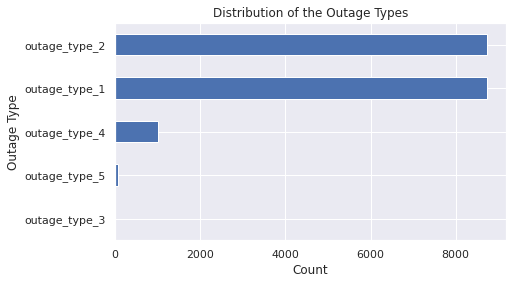

```python
# Plotting the frequency from the above cell
plt.figure(figsize=(7,4))
outage_df.outage_type.value_counts(ascending=True).plot(kind='barh')
plt.ylabel('Outage Type')
plt.xlabel('Count')
plt.title('Distribution of the Outage Types')
plt.show()
```

> `outage_type_1` and `outage_type_2` seems to be most frequent whereas `outage_type_5` and `outage_type_3` are the least

`Wrangling the data for model building`

```python
outage_df = outage_df.pivot_table(values='outage_type',index='id',columns='outage_type',fill_value=0,aggfunc=len)
outage_df.head()
```

| outage_type id | outage_type_1 | outage_type_2 | outage_type_3 | outage_type_4 | outage_type_5 |
| --- | --- | --- | --- | --- | --- |
| 1 | 1 | 0 | 0 | 0 | 0 |
| 2 | 0 | 1 | 0 | 0 | 0 |
| 3 | 1 | 0 | 0 | 0 | 0 |
| 4 | 0 | 0 | 0 | 1 | 0 |
| 5 | 0 | 1 | 0 | 0 | 0 |

```python
outage_df.columns = outage_df.columns.categories
outage_df.head()
```

| id | outage_type_1 | outage_type_2 | outage_type_3 | outage_type_4 | outage_type_5 |
| --- | --- | --- | --- | --- | --- |
| 1 | 1 | 0 | 0 | 0 | 0 |
| 2 | 0 | 1 | 0 | 0 | 0 |
| 3 | 1 | 0 | 0 | 0 | 0 |
| 4 | 0 | 0 | 0 | 1 | 0 |
| 5 | 0 | 1 | 0 | 0 | 0 |

```python
outage_df.reset_index(inplace=True)
outage_df.head()
```

|  | id | outage_type_1 | outage_type_2 | outage_type_3 | outage_type_4 | outage_type_5 |
| --- | --- | --- | --- | --- | --- | --- |
| 0 | 1 | 1 | 0 | 0 | 0 | 0 |
| 1 | 2 | 0 | 1 | 0 | 0 | 0 |
| 2 | 3 | 1 | 0 | 0 | 0 | 0 |
| 3 | 4 | 0 | 0 | 0 | 1 | 0 |
| 4 | 5 | 0 | 1 | 0 | 0 | 0 |

```python
# Checking for any nulls
outage_df.isnull().values.any()
```

```
False
```

```python
# Final shape after processing
outage_df.shape
```

```
(18552, 6)
```

#### 3.3 Report data

```python
#Initial shape of the data
report_df.shape
```

```
(58671, 3)
```

```python
# Summary of the data
report_df.info()
```

```
<class 'pandas.core.frame.DataFrame'>
RangeIndex: 58671 entries, 0 to 58670
Data columns (total 3 columns):
 #   Column           Non-Null Count  Dtype
---  ------           --------------  -----
 0   id               58671 non-null  int64
 1   log_report_type  58671 non-null  object
 2   volume           58671 non-null  int64
dtypes: int64(2), object(1)
memory usage: 1.3+ MB
```

> `id` and `log_report_type` are of type category but it is currently of type int64 and object respectively.

```python
# Changing the data type of the columns mention above
report_df[['id','log_report_type']] = report_df[['id','log_report_type']].astype('category')
```

```python
report_df.describe(include='all')
```

|  | id | log_report_type | volume |
| --- | --- | --- | --- |
| count | 58671.0 | 58671 | 58671.000000 |
| unique | 18552.0 | 386 | NaN |
| top | 15184.0 | log_report_type_312 | NaN |
| freq | 20.0 | 5267 | NaN |
| mean | NaN | NaN | 9.685296 |
| std | NaN | NaN | 27.314433 |
| min | NaN | NaN | 1.000000 |
| 25% | NaN | NaN | 1.000000 |
| 50% | NaN | NaN | 2.000000 |
| 75% | NaN | NaN | 7.000000 |
| max | NaN | NaN | 1310.000000 |

From the above description we can infer that

1. `id` is not unique, which means an `id` has occured multiple times and with possibly different log_report_type
2. Total report types are 386
3. Most frequent `log_report_type` is `log_report_type_312` which has occured `5267` times

**Since there are a total of 386 unique reports it will be difficult to visualize all 386 in a single frame, hence lets see what are the top 20 most frequent log_report_type**

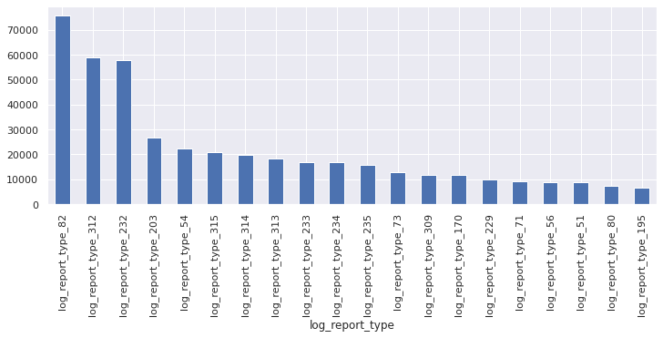

```python
plt.figure(figsize=(12,4))
report_df.groupby('log_report_type')['volume'].sum().nlargest(20).plot(kind='bar')
plt.show()
```

**Now lets see what are the ids that registered most complaints, by visualizing the 50 most frequent ids and their frequencies**

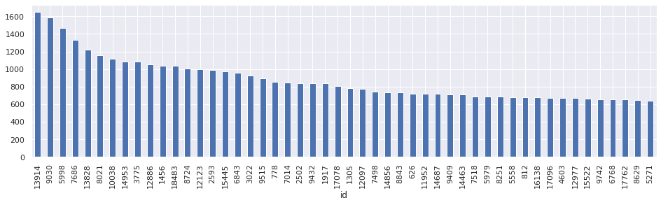

```python
plt.figure(figsize=(16,4))
report_df.groupby('id')['volume'].sum().nlargest(50).plot(kind='bar')
plt.show()
```

`Wrangling data for model building`

```python
report_volume_df = pd.DataFrame(report_df.groupby('id')['volume'].sum()).reset_index()
report_volume_df.rename(columns={'volume':'report_volume'})
report_volume_df.head()
```

|  | id | volume |
| --- | --- | --- |
| 0 | 1 | 5 |
| 1 | 2 | 5 |
| 2 | 3 | 2 |
| 3 | 4 | 3 |
| 4 | 5 | 17 |

```python
report_volume_df
```

|  | id | volume |
| --- | --- | --- |
| 0 | 1 | 5 |
| 1 | 2 | 5 |
| 2 | 3 | 2 |
| 3 | 4 | 3 |
| 4 | 5 | 17 |
| ... | ... | ... |
| 18547 | 18548 | 22 |
| 18548 | 18549 | 8 |
| 18549 | 18550 | 6 |
| 18550 | 18551 | 7 |
| 18551 | 18552 | 48 |

18552 rows × 2 columns

```python
report_df = report_df.pivot_table(values='volume',index='id',columns='log_report_type',fill_value=0,aggfunc=np.sum)
report_df.head()
```

| log_report_type id | log_report_type_1 | log_report_type_10 | log_report_type_100 | log_report_type_101 | log_report_type_102 | log_report_type_103 | log_report_type_104 | log_report_type_105 | log_report_type_106 | log_report_type_107 | log_report_type_108 | log_report_type_109 | log_report_type_11 | log_report_type_110 | log_report_type_111 | log_report_type_112 | log_report_type_113 | log_report_type_114 | log_report_type_115 | log_report_type_116 | log_report_type_117 | log_report_type_118 | log_report_type_119 | log_report_type_12 | log_report_type_120 | log_report_type_121 | log_report_type_122 | log_report_type_123 | log_report_type_124 | … |
| --- | --- | --- | --- | --- | --- | --- | --- | --- | --- | --- | --- | --- | --- | --- | --- | --- | --- | --- | --- | --- | --- | --- | --- | --- | --- | --- | --- | --- | --- | --- |
| 1 | 0 | 0 | 0 | 0 | 0 | 0 | 0 | 0 | 0 | 0 | 0 | 0 | 0 | 0 | 0 | 0 | 0 | 0 | 0 | 0 | 0 | 0 | 0 | 0 | 0 | 0 | 0 | 0 | 0 | … |
| 2 | 0 | 0 | 0 | 0 | 0 | 0 | 0 | 0 | 0 | 0 | 0 | 0 | 0 | 0 | 0 | 0 | 0 | 0 | 0 | 0 | 0 | 0 | 0 | 0 | 0 | 0 | 0 | 0 | 0 | … |
| 3 | 0 | 0 | 0 | 0 | 0 | 0 | 0 | 0 | 0 | 0 | 0 | 0 | 0 | 0 | 0 | 0 | 0 | 0 | 0 | 0 | 0 | 0 | 0 | 0 | 0 | 0 | 0 | 0 | 0 | … |
| 4 | 0 | 0 | 0 | 0 | 0 | 0 | 0 | 0 | 0 | 0 | 0 | 0 | 0 | 0 | 0 | 0 | 0 | 0 | 0 | 0 | 0 | 0 | 0 | 0 | 0 | 0 | 0 | 0 | 0 | … |
| 5 | 0 | 0 | 0 | 0 | 0 | 0 | 0 | 0 | 0 | 0 | 0 | 0 | 0 | 0 | 0 | 0 | 0 | 0 | 0 | 0 | 0 | 0 | 0 | 0 | 0 | 0 | 0 | 0 | 0 | … |

5 rows × 386 columns

```python
report_df.columns = report_df.columns.categories
report_df.head()
```

| id | log_report_type_1 | log_report_type_10 | log_report_type_100 | log_report_type_101 | log_report_type_102 | log_report_type_103 | log_report_type_104 | log_report_type_105 | log_report_type_106 | log_report_type_107 | log_report_type_108 | log_report_type_109 | log_report_type_11 | log_report_type_110 | log_report_type_111 | log_report_type_112 | log_report_type_113 | log_report_type_114 | log_report_type_115 | log_report_type_116 | log_report_type_117 | log_report_type_118 | log_report_type_119 | log_report_type_12 | log_report_type_120 | log_report_type_121 | log_report_type_122 | log_report_type_123 | log_report_type_124 | … |
| --- | --- | --- | --- | --- | --- | --- | --- | --- | --- | --- | --- | --- | --- | --- | --- | --- | --- | --- | --- | --- | --- | --- | --- | --- | --- | --- | --- | --- | --- | --- |
| 1 | 0 | 0 | 0 | 0 | 0 | 0 | 0 | 0 | 0 | 0 | 0 | 0 | 0 | 0 | 0 | 0 | 0 | 0 | 0 | 0 | 0 | 0 | 0 | 0 | 0 | 0 | 0 | 0 | 0 | … |
| 2 | 0 | 0 | 0 | 0 | 0 | 0 | 0 | 0 | 0 | 0 | 0 | 0 | 0 | 0 | 0 | 0 | 0 | 0 | 0 | 0 | 0 | 0 | 0 | 0 | 0 | 0 | 0 | 0 | 0 | … |
| 3 | 0 | 0 | 0 | 0 | 0 | 0 | 0 | 0 | 0 | 0 | 0 | 0 | 0 | 0 | 0 | 0 | 0 | 0 | 0 | 0 | 0 | 0 | 0 | 0 | 0 | 0 | 0 | 0 | 0 | … |
| 4 | 0 | 0 | 0 | 0 | 0 | 0 | 0 | 0 | 0 | 0 | 0 | 0 | 0 | 0 | 0 | 0 | 0 | 0 | 0 | 0 | 0 | 0 | 0 | 0 | 0 | 0 | 0 | 0 | 0 | … |
| 5 | 0 | 0 | 0 | 0 | 0 | 0 | 0 | 0 | 0 | 0 | 0 | 0 | 0 | 0 | 0 | 0 | 0 | 0 | 0 | 0 | 0 | 0 | 0 | 0 | 0 | 0 | 0 | 0 | 0 | … |

5 rows × 386 columns

```python
report_df.reset_index(inplace=True)
report_df.head()
```

|  | id | log_report_type_1 | log_report_type_10 | log_report_type_100 | log_report_type_101 | log_report_type_102 | log_report_type_103 | log_report_type_104 | log_report_type_105 | log_report_type_106 | log_report_type_107 | log_report_type_108 | log_report_type_109 | log_report_type_11 | log_report_type_110 | log_report_type_111 | log_report_type_112 | log_report_type_113 | log_report_type_114 | log_report_type_115 | log_report_type_116 | log_report_type_117 | log_report_type_118 | log_report_type_119 | log_report_type_12 | log_report_type_120 | log_report_type_121 | log_report_type_122 | log_report_type_123 | … |
| --- | --- | --- | --- | --- | --- | --- | --- | --- | --- | --- | --- | --- | --- | --- | --- | --- | --- | --- | --- | --- | --- | --- | --- | --- | --- | --- | --- | --- | --- | --- |
| 0 | 1 | 0 | 0 | 0 | 0 | 0 | 0 | 0 | 0 | 0 | 0 | 0 | 0 | 0 | 0 | 0 | 0 | 0 | 0 | 0 | 0 | 0 | 0 | 0 | 0 | 0 | 0 | 0 | 0 | … |
| 1 | 2 | 0 | 0 | 0 | 0 | 0 | 0 | 0 | 0 | 0 | 0 | 0 | 0 | 0 | 0 | 0 | 0 | 0 | 0 | 0 | 0 | 0 | 0 | 0 | 0 | 0 | 0 | 0 | 0 | … |
| 2 | 3 | 0 | 0 | 0 | 0 | 0 | 0 | 0 | 0 | 0 | 0 | 0 | 0 | 0 | 0 | 0 | 0 | 0 | 0 | 0 | 0 | 0 | 0 | 0 | 0 | 0 | 0 | 0 | 0 | … |
| 3 | 4 | 0 | 0 | 0 | 0 | 0 | 0 | 0 | 0 | 0 | 0 | 0 | 0 | 0 | 0 | 0 | 0 | 0 | 0 | 0 | 0 | 0 | 0 | 0 | 0 | 0 | 0 | 0 | 0 | … |
| 4 | 5 | 0 | 0 | 0 | 0 | 0 | 0 | 0 | 0 | 0 | 0 | 0 | 0 | 0 | 0 | 0 | 0 | 0 | 0 | 0 | 0 | 0 | 0 | 0 | 0 | 0 | 0 | 0 | 0 | … |

5 rows × 387 columns

```python
# Checking if there are any nulls
report_df.isnull().values.any()
```

```
False
```

```python
# Shape of the processed dataset
report_df.shape
```

```
(18552, 387)
```

#### 3.4 Server Data

```python
server_df.head()
```

|  | id | transit_server_type |
| --- | --- | --- |
| 0 | 6597 | transit_server_type_11 |
| 1 | 8011 | transit_server_type_15 |
| 2 | 2597 | transit_server_type_15 |
| 3 | 5022 | transit_server_type_15 |
| 4 | 5022 | transit_server_type_11 |

```python
# Shape of the data prior the processing
server_df.shape
```

```
(31170, 2)
```

```python
# Summary of the data
server_df.info()
```

```
<class 'pandas.core.frame.DataFrame'>
RangeIndex: 31170 entries, 0 to 31169
Data columns (total 2 columns):
 #   Column               Non-Null Count  Dtype
---  ------               --------------  -----
 0   id                   31170 non-null  int64
 1   transit_server_type  31170 non-null  object
dtypes: int64(1), object(1)
memory usage: 487.2+ KB
```

```python
# Changing the data to category type
server_df = server_df.astype('category')
```

```python
# Summary post data conversion
server_df.info()
```

```
<class 'pandas.core.frame.DataFrame'>
RangeIndex: 31170 entries, 0 to 31169
Data columns (total 2 columns):
 #   Column               Non-Null Count  Dtype
---  ------               --------------  -----
 0   id                   31170 non-null  category
 1   transit_server_type  31170 non-null  category
dtypes: category(2)
memory usage: 879.3 KB
```

```python
# Data description
server_df.describe(include='all')
```

|  | id | transit_server_type |
| --- | --- | --- |
| count | 31170 | 31170 |
| unique | 18552 | 53 |
| top | 10354 | transit_server_type_11 |
| freq | 11 | 7888 |

From the description we can infer the following

1. There 18552 unique `id`s
2. Most frequently occuring `id` is `10354` which is occuring 11 times
3. There are 53 unique `transit_server_type`s
4. Most frequent transit server type is `transit_server_type_11` which is occuring `7888` times

**Let's visualize the 20 most frequent transit_server_type and their frequencies**

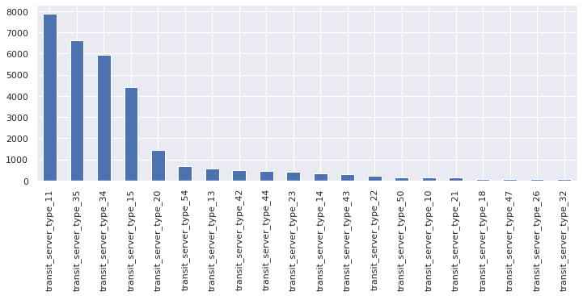

```python
plt.figure(figsize=(12,4))
server_df.transit_server_type.value_counts().nlargest(20).plot(kind='bar')
plt.show()
```

`Wrangling data for model building`

```python
server_df = server_df.pivot_table(values='transit_server_type',index='id',columns='transit_server_type',fill_value=0,aggfunc=len)
server_df.head()
```

| transit_server_type id | transit_server_type_1 | transit_server_type_10 | transit_server_type_11 | transit_server_type_12 | transit_server_type_13 | transit_server_type_14 | transit_server_type_15 | transit_server_type_17 | transit_server_type_18 | transit_server_type_19 | transit_server_type_2 | transit_server_type_20 | transit_server_type_21 | transit_server_type_22 | transit_server_type_23 | transit_server_type_24 | transit_server_type_25 | transit_server_type_26 | transit_server_type_27 | transit_server_type_28 | transit_server_type_29 | transit_server_type_3 | transit_server_type_30 | transit_server_type_31 | transit_server_type_32 | transit_server_type_33 | transit_server_type_34 | transit_server_type_35 | transit_server_type_36 | … |
| --- | --- | --- | --- | --- | --- | --- | --- | --- | --- | --- | --- | --- | --- | --- | --- | --- | --- | --- | --- | --- | --- | --- | --- | --- | --- | --- | --- | --- | --- | --- |
| 1 | 0 | 0 | 1 | 0 | 1 | 0 | 0 | 0 | 0 | 0 | 0 | 0 | 0 | 0 | 0 | 0 | 0 | 0 | 0 | 0 | 0 | 0 | 0 | 0 | 0 | 0 | 0 | 0 | 0 | … |
| 2 | 0 | 0 | 0 | 0 | 0 | 0 | 0 | 0 | 0 | 0 | 0 | 0 | 0 | 0 | 0 | 0 | 0 | 0 | 0 | 0 | 0 | 0 | 0 | 0 | 0 | 0 | 1 | 1 | 0 | … |
| 3 | 0 | 0 | 1 | 0 | 0 | 0 | 0 | 0 | 0 | 0 | 0 | 0 | 0 | 0 | 0 | 0 | 0 | 0 | 0 | 0 | 0 | 0 | 0 | 0 | 0 | 0 | 0 | 0 | 0 | … |
| 4 | 0 | 0 | 0 | 0 | 0 | 0 | 0 | 0 | 0 | 0 | 0 | 0 | 0 | 0 | 0 | 0 | 0 | 0 | 0 | 0 | 0 | 0 | 0 | 0 | 0 | 0 | 0 | 0 | 0 | … |
| 5 | 0 | 0 | 0 | 0 | 0 | 0 | 0 | 0 | 0 | 0 | 0 | 0 | 0 | 0 | 0 | 0 | 0 | 0 | 0 | 0 | 0 | 0 | 0 | 0 | 0 | 0 | 1 | 1 | 0 | … |

```python
server_df.columns = server_df.columns.categories
server_df.head()
```

| id | transit_server_type_1 | transit_server_type_10 | transit_server_type_11 | transit_server_type_12 | transit_server_type_13 | transit_server_type_14 | transit_server_type_15 | transit_server_type_17 | transit_server_type_18 | transit_server_type_19 | transit_server_type_2 | transit_server_type_20 | transit_server_type_21 | transit_server_type_22 | transit_server_type_23 | transit_server_type_24 | transit_server_type_25 | transit_server_type_26 | transit_server_type_27 | transit_server_type_28 | transit_server_type_29 | transit_server_type_3 | transit_server_type_30 | transit_server_type_31 | transit_server_type_32 | transit_server_type_33 | transit_server_type_34 | transit_server_type_35 | transit_server_type_36 | … |
| --- | --- | --- | --- | --- | --- | --- | --- | --- | --- | --- | --- | --- | --- | --- | --- | --- | --- | --- | --- | --- | --- | --- | --- | --- | --- | --- | --- | --- | --- | --- |
| 1 | 0 | 0 | 1 | 0 | 1 | 0 | 0 | 0 | 0 | 0 | 0 | 0 | 0 | 0 | 0 | 0 | 0 | 0 | 0 | 0 | 0 | 0 | 0 | 0 | 0 | 0 | 0 | 0 | 0 | … |
| 2 | 0 | 0 | 0 | 0 | 0 | 0 | 0 | 0 | 0 | 0 | 0 | 0 | 0 | 0 | 0 | 0 | 0 | 0 | 0 | 0 | 0 | 0 | 0 | 0 | 0 | 0 | 1 | 1 | 0 | … |
| 3 | 0 | 0 | 1 | 0 | 0 | 0 | 0 | 0 | 0 | 0 | 0 | 0 | 0 | 0 | 0 | 0 | 0 | 0 | 0 | 0 | 0 | 0 | 0 | 0 | 0 | 0 | 0 | 0 | 0 | … |
| 4 | 0 | 0 | 0 | 0 | 0 | 0 | 0 | 0 | 0 | 0 | 0 | 0 | 0 | 0 | 0 | 0 | 0 | 0 | 0 | 0 | 0 | 0 | 0 | 0 | 0 | 0 | 0 | 0 | 0 | … |
| 5 | 0 | 0 | 0 | 0 | 0 | 0 | 0 | 0 | 0 | 0 | 0 | 0 | 0 | 0 | 0 | 0 | 0 | 0 | 0 | 0 | 0 | 0 | 0 | 0 | 0 | 0 | 1 | 1 | 0 | … |

```python
server_df= server_df.reset_index()
server_df.head()
```

|  | id | transit_server_type_1 | transit_server_type_10 | transit_server_type_11 | transit_server_type_12 | transit_server_type_13 | transit_server_type_14 | transit_server_type_15 | transit_server_type_17 | transit_server_type_18 | transit_server_type_19 | transit_server_type_2 | transit_server_type_20 | transit_server_type_21 | transit_server_type_22 | transit_server_type_23 | transit_server_type_24 | transit_server_type_25 | transit_server_type_26 | transit_server_type_27 | transit_server_type_28 | transit_server_type_29 | transit_server_type_3 | transit_server_type_30 | transit_server_type_31 | transit_server_type_32 | transit_server_type_33 | transit_server_type_34 | transit_server_type_35 | … |
| --- | --- | --- | --- | --- | --- | --- | --- | --- | --- | --- | --- | --- | --- | --- | --- | --- | --- | --- | --- | --- | --- | --- | --- | --- | --- | --- | --- | --- | --- | --- |
| 0 | 1 | 0 | 0 | 1 | 0 | 1 | 0 | 0 | 0 | 0 | 0 | 0 | 0 | 0 | 0 | 0 | 0 | 0 | 0 | 0 | 0 | 0 | 0 | 0 | 0 | 0 | 0 | 0 | 0 | … |
| 1 | 2 | 0 | 0 | 0 | 0 | 0 | 0 | 0 | 0 | 0 | 0 | 0 | 0 | 0 | 0 | 0 | 0 | 0 | 0 | 0 | 0 | 0 | 0 | 0 | 0 | 0 | 0 | 1 | 1 | … |
| 2 | 3 | 0 | 0 | 1 | 0 | 0 | 0 | 0 | 0 | 0 | 0 | 0 | 0 | 0 | 0 | 0 | 0 | 0 | 0 | 0 | 0 | 0 | 0 | 0 | 0 | 0 | 0 | 0 | 0 | … |
| 3 | 4 | 0 | 0 | 0 | 0 | 0 | 0 | 0 | 0 | 0 | 0 | 0 | 0 | 0 | 0 | 0 | 0 | 0 | 0 | 0 | 0 | 0 | 0 | 0 | 0 | 0 | 0 | 0 | 0 | … |
| 4 | 5 | 0 | 0 | 0 | 0 | 0 | 0 | 0 | 0 | 0 | 0 | 0 | 0 | 0 | 0 | 0 | 0 | 0 | 0 | 0 | 0 | 0 | 0 | 0 | 0 | 0 | 0 | 1 | 1 | … |

```python
# checking for any nulls
server_df.isnull().values.any()
```

```
False
```

```python
# shape of the dataset post processing
server_df.shape
```

```
(18552, 54)
```

#### 3.5 Train Data

```python
train_df.head()
```

|  | id | area_code | outage_duration |
| --- | --- | --- | --- |
| 0 | 13366 | area_415 | 1 |
| 1 | 6783 | area_474 | 0 |
| 2 | 9519 | area_931 | 1 |
| 3 | 10202 | area_700 | 1 |
| 4 | 4555 | area_600 | 2 |

```python
# Shape of the train data before processing
train_df.shape
```

```
(5904, 3)
```

```python
# Summary of the dataset
train_df.info()
```

```
<class 'pandas.core.frame.DataFrame'>
RangeIndex: 5904 entries, 0 to 5903
Data columns (total 3 columns):
 #   Column           Non-Null Count  Dtype
---  ------           --------------  -----
 0   id               5904 non-null   int64
 1   area_code        5904 non-null   object
 2   outage_duration  5904 non-null   int64
dtypes: int64(2), object(1)
memory usage: 138.5+ KB
```

```python
# Changing the type of the data
train_df = train_df.astype('category')
```

```python
# Summary post change of the type
train_df.info()
```

```
<class 'pandas.core.frame.DataFrame'>
RangeIndex: 5904 entries, 0 to 5903
Data columns (total 3 columns):
 #   Column           Non-Null Count  Dtype
---  ------           --------------  -----
 0   id               5904 non-null   category
 1   area_code        5904 non-null   category
 2   outage_duration  5904 non-null   category
dtypes: category(3)
memory usage: 282.0 KB
```

```python
# data description
train_df.describe()
```

|  | id | area_code | outage_duration |
| --- | --- | --- | --- |
| count | 5904 | 5904 | 5904 |
| unique | 5904 | 876 | 3 |
| top | 18550 | area_821 | 0 |
| freq | 1 | 67 | 3827 |

From the description above we can infer that,

1. Each row has a unique `id` and there are a total of `5904` ids
2. There are a total `876` `aread_codes`
3. `area_821` is the most frequently occuring with the frequency of `67`

**Lets understand the distribution of the outage_duration with help of a pie-chart**

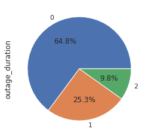

```python
train_df.outage_duration.value_counts().plot(kind='pie',autopct='%1.1f%%')
plt.show()
```

There is clear class imbalance in the train data

## 4. Answers to the operations team

#### 4.1 Which areas are most prone to long outage durations?

```python
# Filtering the area with outage duration is long, and getting the count of occurence
long_outage_area_count = train_df.loc[train_df.outage_duration==2].area_code.value_counts()
```

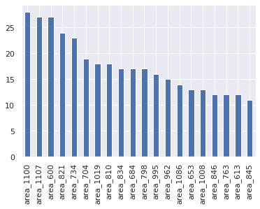

```python
# Plotting top 20 areas most prone to long outage duration
long_outage_area_count.nlargest(20).plot(kind='bar')
plt.show()
```

```python
# Getting the names of all the areas with outage_duration long in a list in decreasing order
long_outage_areas = list(long_outage_area_count[long_outage_area_count>0].index)
```

```python
# printing the above list
print(long_outage_areas)
```

```
['area_1100', 'area_1107', 'area_600', 'area_821', 'area_734', 'area_704', 'area_1019', 'area_810', 'area_834', 'area_684', 'area_798', 'area_995', 'area_962', 'area_1086', 'area_653', 'area_1008', 'area_846', 'area_763', 'area_613', 'area_845', 'area_638', 'area_1042', 'area_1052', 'area_895', 'are…
```

#### 4.2 Which broadband types are suspect of long outage durations?

```python
# Filtering long outage_duration, merging the train_data with broadband_df, getting the sum along axis=0 , sorting in descending
broadband_types_long_outage = train_df.loc[train_df.outage_duration==2][['id']]\
                                .merge(broadband_df,on='id').sum().drop(index='id')\
                                    .sort_values(ascending=False)
print(broadband_types_long_outage)
```

```
ADSL 1              544
ADSL 2               82
ADSL 2+              26
Fiber 1              17
Fiber Ultra          10
Cable                 9
Fiber 2               4
BPL                   4
Fiber Ultra Max       3
Fiber High Speed      1
dtype: int64
```

As we can see the long outage duration has ADSL 1 as the most common type of broadband followed by other ADSL types. Lets visualize the same in a bar chart

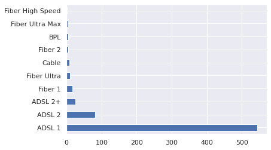

```python
broadband_types_long_outage.plot(kind='barh')
plt.show()
```

#### 4.3 Any other recommendations to improve the detection of outage durations.

1. As we saw some of the datasets had predictor variables of categorical type which huge number of categories, we can group data and reduce them, to improve our detection of outage durations
2. From the pie chart we saw that the training data has some class imbalance, hence using techniques like smoting etc. can improve the detection of the outage duration

## 5. Model Building

```python
# test data set
test_df = pd.read_csv('data/test_data-1593798292529.csv')
test_df.head()
```

|  | id | area_code |
| --- | --- | --- |
| 0 | 3340 | area_344 |
| 1 | 14067 | area_933 |
| 2 | 1134 | area_16 |
| 3 | 27 | area_793 |
| 4 | 9793 | area_344 |

```python
test_df.area_code = test_df.area_code.astype('category')
```

### 5.1 Pre-Processing

#### 5.1.1 Merging datasets and splitting data into input and output(X and y)

```python
# merging train data with the other dataframes

train_dfs = [train_df.drop('area_code',axis=1),broadband_df,outage_df,report_df,server_df]
test_dfs = [test_df.drop('area_code',axis=1),broadband_df,outage_df,report_df,server_df]
train_final = reduce(lambda left,right: pd.merge(left,right,on='id'), train_dfs)
test_final =  reduce(lambda left,right: pd.merge(left,right,on='id'), test_dfs)
train_final.set_index('id',inplace=True)
```

```python
from imblearn.over_sampling import SMOTE
smote = SMOTE('not majority')
X_smote,y_smote = smote.fit_sample(train_final.drop('outage_duration',axis=1),train_final.outage_duration)
X_smote = pd.DataFrame(X_smote,columns = train_final.drop('outage_duration',axis=1).columns )
X_train_sm, X_val_sm, y_train_sm, y_val_sm = train_test_split(X_smote, y_smote, test_size=0.2, random_state=42)
```

```python
train_final.shape,test_final.shape
```

```
((5904, 455), (1477, 455))
```

```python
X_train, X_val, y_train, y_val = train_test_split(train_final.drop('outage_duration',axis=1), train_df.outage_duration, test_size=0.2, random_state=42)

X_test = test_final.set_index('id')
```

```python
X_train.shape,y_train.shape,X_val.shape,y_val.shape,X_test.shape
```

```
((4723, 454), (4723,), (1181, 454), (1181,), (1477, 454))
```

#### 5.1.2 Pipeling of pre-processing

```python
from sklearn.metrics import accuracy_score
```

```python
from sklearn.preprocessing import MinMaxScaler, OneHotEncoder
from sklearn.pipeline import Pipeline
from sklearn.compose import ColumnTransformer
```

```python
num_attr = list(X_train.select_dtypes('number').columns)
cat_attr = list(X_train.select_dtypes('category').columns)
```

```python
numeric_transformer = Pipeline(steps=[('scaler', MinMaxScaler())])

categorical_transformer = Pipeline(steps=[('onehot', OneHotEncoder(handle_unknown='ignore',))])

preprocessor = ColumnTransformer(
    transformers=[
        ('num', numeric_transformer, num_attr),
        ('cat', categorical_transformer, cat_attr)])
```

```python
import torch
from torch import nn
import torch.nn.functional as F
from torchvision import transforms
import torch.optim as optim
```

```python
device = 'cuda' if torch.cuda.is_available() else 'cpu'
```

```python
X_train_np = preprocessor.fit_transform(X_smote)
X_train_tensor = torch.from_numpy(preprocessor.fit_transform(train_final.drop('outage_duration',axis=1))).float().to(device)
y_train_tensor =  torch.Tensor(train_final.outage_duration.values).long().to(device)
```

```python
class Classifier(nn.Module):
    def __init__(self):
        super().__init__()
        self.fc1 = nn.Linear(454, 100)
        self.fc2 = nn.Linear(100, 50)
        self.fc3 = nn.Linear(50, 3)


        self.dropout = nn.Dropout(p=0.1)


    def forward(self, x):
        # make sure input tensor is flattened
        x = self.dropout(F.leaky_relu(self.fc1(x)))
        x = self.dropout(F.leaky_relu(self.fc2(x)))
        x = F.log_softmax(self.fc3(x), dim=1)

        return x
```

```python
model = Classifier().to(device)
criterion = nn.NLLLoss()
optimizer = optim.Adamax(model.parameters(), lr=0.001)
```

```python
epochs = 10
for i in range(epochs):
    log_ps = model(X_train_tensor)
    loss = criterion(log_ps, y_train_tensor)
    optimizer.zero_grad()
    loss.backward()
    optimizer.step()
    print(f"Training loss: {loss.item()}")
```

```
Training loss: 1.1478767395019531
Training loss: 1.1414883136749268
Training loss: 1.1358050107955933
Training loss: 1.1303311586380005
Training loss: 1.1247687339782715
Training loss: 1.1196058988571167
Training loss: 1.1146119832992554
Training loss: 1.1099295616149902
Training loss: 1.1052035093307495
Training loss: 1.100447177886963
```

```python
from torch.utils.data.sampler import SubsetRandomSampler
from torch.utils.data import DataLoader, TensorDataset

def create_datasets(batch_size):

    # percentage of training set to use as validation
    valid_size = 0.2

    dataset = TensorDataset( X_train_tensor, y_train_tensor )

    # obtain training indices that will be used for validation
    num_train = len(train_final)
    indices = list(range(num_train))
    np.random.shuffle(indices)
    split = int(np.floor(valid_size * num_train))
    train_idx, valid_idx = indices[split:], indices[:split]

    # define samplers for obtaining training and validation batches
    train_sampler = SubsetRandomSampler(train_idx)
    valid_sampler = SubsetRandomSampler(valid_idx)

    # load training data in batches
    train_loader = torch.utils.data.DataLoader(dataset,
                                               batch_size=batch_size,
                                               sampler=train_sampler,
                                               num_workers=0)

    # load validation data in batches
    valid_loader = torch.utils.data.DataLoader(dataset,
                                               batch_size=batch_size,
                                               sampler=valid_sampler,
                                               num_workers=0)

    return train_loader,  valid_loader
```

```python
from pytorchtools import EarlyStopping

def train_model(model, batch_size, patience, n_epochs):

    # to track the training loss as the model trains
    train_losses = []
    # to track the validation loss as the model trains
    valid_losses = []
    # to track the average training loss per epoch as the model trains
    avg_train_losses = []
    # to track the average validation loss per epoch as the model trains
    avg_valid_losses = []

    # initialize the early_stopping object
    early_stopping = EarlyStopping(patience=patience, verbose=True)

    for epoch in range(1, n_epochs + 1):

        ###################
        # train the model #
        ###################
        model.train() # prep model for training
        for batch, (data, target) in enumerate(train_loader, 1):
            # clear the gradients of all optimized variables
            optimizer.zero_grad()
            # forward pass: compute predicted outputs by passing inputs to the model
            output = model(data)
            # calculate the loss
            loss = criterion(output, target)
            # backward pass: compute gradient of the loss with respect to model parameters
            loss.backward()
            # perform a single optimization step (parameter update)
            optimizer.step()
            # record training loss
            train_losses.append(loss.item())

        ######################
        # validate the model #
        ######################
        model.eval() # prep model for evaluation
        for data, target in valid_loader:
            # forward pass: compute predicted outputs by passing inputs to the model
            output = model(data)
            # calculate the loss
            loss = criterion(output, target)
            # record validation loss
            valid_losses.append(loss.item())

        # print training/validation statistics
        # calculate average loss over an epoch
        train_loss = np.average(train_losses)
        valid_loss = np.average(valid_losses)
        avg_train_losses.append(train_loss)
        avg_valid_losses.append(valid_loss)

        epoch_len = len(str(n_epochs))

        print_msg = (f'[{epoch:>{epoch_len}}/{n_epochs:>{epoch_len}}] ' +
                     f'train_loss: {train_loss:.5f} ' +
                     f'valid_loss: {valid_loss:.5f}')

        print(print_msg)

        # clear lists to track next epoch
        train_losses = []
        valid_losses = []

        # early_stopping needs the validation loss to check if it has decresed,
        # and if it has, it will make a checkpoint of the current model
        early_stopping(valid_loss, model)

        if early_stopping.early_stop:
            print("Early stopping")
            break

    # load the last checkpoint with the best model
    model.load_state_dict(torch.load('checkpoint.pt'))

    return  model, avg_train_losses, avg_valid_losses
```

```python
batch_size = 1000
n_epochs = 5000

train_loader, valid_loader = create_datasets(batch_size)

# early stopping patience; how long to wait after last time validation loss improved.
patience = 300

model, train_loss, valid_loss = train_model(model, batch_size, patience, n_epochs)
```

```
[   1/5000] train_loss: 1.08689 valid_loss: 1.07434
Validation loss decreased (inf --> 1.074345).  Saving model ...
[   2/5000] train_loss: 1.06255 valid_loss: 1.05241
Validation loss decreased (1.074345 --> 1.052407).  Saving model ...
[   3/5000] train_loss: 1.03519 valid_loss: 1.01821
Validation loss decreased (1.052407 --> 1.018208).  Saving model ...
[   4/5000] train_loss: 1.00243 valid_loss: 0.98672
Validation loss decreased (1.018208 --> 0.986721).  Saving model ...
[   5/5000] train_loss: 0.96715 valid_loss: 0.94553
Validation loss decreased (0.986721 --> 0.945532).  Saving model ...
[   6/5000] train_loss: 0.92836 valid_loss: 0.93787
Validation loss decreased (0.945532 --> 0.937870).  Saving model ...
[   7/5000] train_loss: 0.88988 valid_loss: 0.90139
Validation loss decreased (0.937870 --> 0.901387).  Saving model ...
[   8/5000] train_loss: 0.85861 valid_loss: 0.85070
Validation loss decreased (0.901387 --> 0.850696).  Saving model ...
[   9/5000] train_loss: 0.83243 valid_loss: 0.81459
Validation loss decreased (0.850696 --> 0.814594).  Saving model ...
[  10/5000] train_loss: 0.81545 valid_loss: 0.82429
EarlyStopping counter: 1 out of 300
[  11/5000] train_loss: 0.80048 valid_loss: 0.80821
Validation loss decreased (0.814594 --> 0.808208).  Saving model ...
[  12/5000] train_loss: 0.78641 valid_loss: 0.79672
Validation loss decreased (0.808208 --> 0.796715).  Saving model ...
[  13/5000] train_loss: 0.78018 valid_loss: 0.79428
Validation loss decreased (0.796715 --> 0.794280).  Saving model ...
[  14/5000] train_loss: 0.76757 valid_loss: 0.77779
Validation loss decreased (0.794280 --> 0.777789).  Saving model ...
[  15/5000] train_loss: 0.76207 valid_loss: 0.78792
EarlyStopping counter: 1 out of 300
[  16/5000] train_loss: 0.75636 valid_loss: 0.77307
Validation loss decreased (0.777789 --> 0.773070).  Saving model ...
[  17/5000] train_loss: 0.75082 valid_loss: 0.79081
EarlyStopping counter: 1 out of 300
[  18/5000] train_loss: 0.74632 valid_loss: 0.75116
Validation loss decreased (0.773070 --> 0.751156).  Saving model ...
[  19/5000] train_loss: 0.74267 valid_loss: 0.77858
EarlyStopping counter: 1 out of 300
[  20/5000] train_loss: 0.73507 valid_loss: 0.72468
Validation loss decreased (0.751156 --> 0.724680).  Saving model ...
```

[output cut: 1032 more lines]

```
[ 537/5000] train_loss: 0.45173 valid_loss: 0.69222
EarlyStopping counter: 294 out of 300
[ 538/5000] train_loss: 0.44975 valid_loss: 0.71873
EarlyStopping counter: 295 out of 300
[ 539/5000] train_loss: 0.44770 valid_loss: 0.66525
EarlyStopping counter: 296 out of 300
[ 540/5000] train_loss: 0.45047 valid_loss: 0.64009
EarlyStopping counter: 297 out of 300
[ 541/5000] train_loss: 0.44602 valid_loss: 0.64014
EarlyStopping counter: 298 out of 300
[ 542/5000] train_loss: 0.44579 valid_loss: 0.65492
EarlyStopping counter: 299 out of 300
[ 543/5000] train_loss: 0.44821 valid_loss: 0.67490
EarlyStopping counter: 300 out of 300
Early stopping
```

```python
y_pred = model(X_train_tensor)

y_pred = torch.argmax(y_pred,axis=1)
```

```python
accuracy_score(np.array(y_train_tensor.to('cpu')),np.array( y_pred.to('cpu')))
```

```
0.7696476964769647
```

## 5. Summary

- We described the problem statement
- Imported necessary libraries to perform EDA
- Read all the datasets in the raw format
- Data Wrangling to get the necessary format for EDA and model building
- Explored each dataset with description and EDA
- Answers to the questions by the operations team
- Recommendations to improve the detection of outage durations

## 6. Next Steps

- Splitting the train dataset into train and validation
- Trying models in the order of the increasing complexity
- Analyzing the performance(bias/variance) of different models
- Tweaking the models and analyzing the performance
- Choosing the best model